# Risk Factor Analysis

## Outcome Variable

**Outcome Variable:** swasted

## Predictor Variables

**Intervention Variable:** feducyrs

**Adjustment Set:**

unadjusted

## Stratifying Variables

The analysis was stratified on these variable(s):

- agecat
- studyid
- country

## Data Summary

| agecat | studyid | country | feducyrs | swasted | n_cell | n |
| --- | --- | --- | --- | --- | --- | --- |
| Birth | ki0047075b-MAL-ED | BANGLADESH | Low | 0 | 32 | 134 |
| Birth | ki0047075b-MAL-ED | BANGLADESH | Low | 1 | 3 | 134 |
| Birth | ki0047075b-MAL-ED | BANGLADESH | Medium | 0 | 49 | 134 |
| Birth | ki0047075b-MAL-ED | BANGLADESH | Medium | 1 | 1 | 134 |
| Birth | ki0047075b-MAL-ED | BANGLADESH | High | 0 | 47 | 134 |
| Birth | ki0047075b-MAL-ED | BANGLADESH | High | 1 | 2 | 134 |
| Birth | ki0047075b-MAL-ED | INDIA | Low | 0 | 46 | 121 |
| Birth | ki0047075b-MAL-ED | INDIA | Low | 1 | 2 | 121 |
| Birth | ki0047075b-MAL-ED | INDIA | Medium | 0 | 35 | 121 |
| Birth | ki0047075b-MAL-ED | INDIA | Medium | 1 | 0 | 121 |
| Birth | ki0047075b-MAL-ED | INDIA | High | 0 | 38 | 121 |
| Birth | ki0047075b-MAL-ED | INDIA | High | 1 | 0 | 121 |
| Birth | ki0047075b-MAL-ED | NEPAL | Low | 0 | 18 | 64 |
| Birth | ki0047075b-MAL-ED | NEPAL | Low | 1 | 0 | 64 |
| Birth | ki0047075b-MAL-ED | NEPAL | Medium | 0 | 19 | 64 |
| Birth | ki0047075b-MAL-ED | NEPAL | Medium | 1 | 0 | 64 |
| Birth | ki0047075b-MAL-ED | NEPAL | High | 0 | 27 | 64 |
| Birth | ki0047075b-MAL-ED | NEPAL | High | 1 | 0 | 64 |
| Birth | ki0047075b-MAL-ED | PERU | Low | 0 | 63 | 230 |
| Birth | ki0047075b-MAL-ED | PERU | Low | 1 | 0 | 230 |
| Birth | ki0047075b-MAL-ED | PERU | Medium | 0 | 55 | 230 |
| Birth | ki0047075b-MAL-ED | PERU | Medium | 1 | 0 | 230 |
| Birth | ki0047075b-MAL-ED | PERU | High | 0 | 112 | 230 |
| Birth | ki0047075b-MAL-ED | PERU | High | 1 | 0 | 230 |
| Birth | ki0047075b-MAL-ED | SOUTH AFRICA | Low | 0 | 30 | 91 |
| Birth | ki0047075b-MAL-ED | SOUTH AFRICA | Low | 1 | 0 | 91 |
| Birth | ki0047075b-MAL-ED | SOUTH AFRICA | Medium | 0 | 26 | 91 |
| Birth | ki0047075b-MAL-ED | SOUTH AFRICA | Medium | 1 | 0 | 91 |
| Birth | ki0047075b-MAL-ED | SOUTH AFRICA | High | 0 | 35 | 91 |
| Birth | ki0047075b-MAL-ED | SOUTH AFRICA | High | 1 | 0 | 91 |

[output cut: 288 more lines]

The following strata were considered:

- agecat: 24 months, studyid: ki0047075b-MAL-ED, country: BANGLADESH
- agecat: 24 months, studyid: ki0047075b-MAL-ED, country: INDIA
- agecat: 24 months, studyid: ki0047075b-MAL-ED, country: NEPAL
- agecat: 24 months, studyid: ki0047075b-MAL-ED, country: PERU
- agecat: 24 months, studyid: ki0047075b-MAL-ED, country: SOUTH AFRICA
- agecat: 24 months, studyid: ki0047075b-MAL-ED, country: TANZANIA, UNITED REPUBLIC OF
- agecat: 24 months, studyid: ki1017093b-PROVIDE, country: BANGLADESH
- agecat: 24 months, studyid: ki1017093c-NIH-Crypto, country: BANGLADESH
- agecat: 24 months, studyid: ki1066203-TanzaniaChild2, country: TANZANIA, UNITED REPUBLIC OF
- agecat: 24 months, studyid: ki1113344-GMS-Nepal, country: NEPAL
- agecat: 24 months, studyid: ki1119695-PROBIT, country: BELARUS
- agecat: 24 months, studyid: ki1126311-ZVITAMBO, country: ZIMBABWE
- agecat: 24 months, studyid: ki1135781-COHORTS, country: GUATEMALA
- agecat: 24 months, studyid: ki1135781-COHORTS, country: INDIA
- agecat: 24 months, studyid: ki1135781-COHORTS, country: PHILIPPINES
- agecat: 24 months, studyid: ki1148112-LCNI-5, country: MALAWI
- agecat: 24 months, studyid: kiGH5241-JiVitA-3, country: BANGLADESH
- agecat: 24 months, studyid: kiGH5241-JiVitA-4, country: BANGLADESH
- agecat: 6 months, studyid: ki0047075b-MAL-ED, country: BANGLADESH
- agecat: 6 months, studyid: ki0047075b-MAL-ED, country: INDIA
- agecat: 6 months, studyid: ki0047075b-MAL-ED, country: NEPAL
- agecat: 6 months, studyid: ki0047075b-MAL-ED, country: PERU
- agecat: 6 months, studyid: ki0047075b-MAL-ED, country: SOUTH AFRICA
- agecat: 6 months, studyid: ki0047075b-MAL-ED, country: TANZANIA, UNITED REPUBLIC OF
- agecat: 6 months, studyid: ki1000304b-SAS-CompFeed, country: INDIA
- agecat: 6 months, studyid: ki1000304b-SAS-FoodSuppl, country: INDIA
- agecat: 6 months, studyid: ki1017093b-PROVIDE, country: BANGLADESH
- agecat: 6 months, studyid: ki1017093c-NIH-Crypto, country: BANGLADESH
- agecat: 6 months, studyid: ki1066203-TanzaniaChild2, country: TANZANIA, UNITED REPUBLIC OF
- agecat: 6 months, studyid: ki1113344-GMS-Nepal, country: NEPAL
- agecat: 6 months, studyid: ki1119695-PROBIT, country: BELARUS
- agecat: 6 months, studyid: ki1126311-ZVITAMBO, country: ZIMBABWE
- agecat: 6 months, studyid: ki1135781-COHORTS, country: GUATEMALA
- agecat: 6 months, studyid: ki1135781-COHORTS, country: INDIA
- agecat: 6 months, studyid: ki1135781-COHORTS, country: PHILIPPINES
- agecat: 6 months, studyid: ki1148112-LCNI-5, country: MALAWI
- agecat: 6 months, studyid: kiGH5241-JiVitA-3, country: BANGLADESH
- agecat: 6 months, studyid: kiGH5241-JiVitA-4, country: BANGLADESH
- agecat: Birth, studyid: ki0047075b-MAL-ED, country: BANGLADESH
- agecat: Birth, studyid: ki0047075b-MAL-ED, country: INDIA
- agecat: Birth, studyid: ki0047075b-MAL-ED, country: NEPAL
- agecat: Birth, studyid: ki0047075b-MAL-ED, country: PERU
- agecat: Birth, studyid: ki0047075b-MAL-ED, country: SOUTH AFRICA
- agecat: Birth, studyid: ki0047075b-MAL-ED, country: TANZANIA, UNITED REPUBLIC OF
- agecat: Birth, studyid: ki1000304b-SAS-CompFeed, country: INDIA
- agecat: Birth, studyid: ki1017093c-NIH-Crypto, country: BANGLADESH
- agecat: Birth, studyid: ki1119695-PROBIT, country: BELARUS
- agecat: Birth, studyid: ki1126311-ZVITAMBO, country: ZIMBABWE
- agecat: Birth, studyid: ki1135781-COHORTS, country: GUATEMALA
- agecat: Birth, studyid: ki1135781-COHORTS, country: INDIA
- agecat: Birth, studyid: ki1135781-COHORTS, country: PHILIPPINES
- agecat: Birth, studyid: kiGH5241-JiVitA-3, country: BANGLADESH
- agecat: Birth, studyid: kiGH5241-JiVitA-4, country: BANGLADESH

### Dropped Strata

Some strata were dropped due to rare outcomes:

- agecat: Birth, studyid: ki0047075b-MAL-ED, country: BANGLADESH
- agecat: Birth, studyid: ki0047075b-MAL-ED, country: INDIA
- agecat: Birth, studyid: ki0047075b-MAL-ED, country: NEPAL
- agecat: Birth, studyid: ki0047075b-MAL-ED, country: PERU
- agecat: Birth, studyid: ki0047075b-MAL-ED, country: SOUTH AFRICA
- agecat: Birth, studyid: ki0047075b-MAL-ED, country: TANZANIA, UNITED REPUBLIC OF
- agecat: Birth, studyid: ki1000304b-SAS-CompFeed, country: INDIA
- agecat: Birth, studyid: ki1017093c-NIH-Crypto, country: BANGLADESH
- agecat: Birth, studyid: kiGH5241-JiVitA-4, country: BANGLADESH
- agecat: 6 months, studyid: ki0047075b-MAL-ED, country: BANGLADESH
- agecat: 6 months, studyid: ki0047075b-MAL-ED, country: INDIA
- agecat: 6 months, studyid: ki0047075b-MAL-ED, country: NEPAL
- agecat: 6 months, studyid: ki0047075b-MAL-ED, country: PERU
- agecat: 6 months, studyid: ki0047075b-MAL-ED, country: SOUTH AFRICA
- agecat: 6 months, studyid: ki0047075b-MAL-ED, country: TANZANIA, UNITED REPUBLIC OF
- agecat: 6 months, studyid: ki1017093b-PROVIDE, country: BANGLADESH
- agecat: 6 months, studyid: ki1017093c-NIH-Crypto, country: BANGLADESH
- agecat: 6 months, studyid: ki1066203-TanzaniaChild2, country: TANZANIA, UNITED REPUBLIC OF
- agecat: 6 months, studyid: ki1113344-GMS-Nepal, country: NEPAL
- agecat: 6 months, studyid: ki1119695-PROBIT, country: BELARUS
- agecat: 6 months, studyid: ki1135781-COHORTS, country: GUATEMALA
- agecat: 6 months, studyid: ki1148112-LCNI-5, country: MALAWI
- agecat: 6 months, studyid: kiGH5241-JiVitA-4, country: BANGLADESH
- agecat: 24 months, studyid: ki0047075b-MAL-ED, country: BANGLADESH
- agecat: 24 months, studyid: ki0047075b-MAL-ED, country: INDIA
- agecat: 24 months, studyid: ki0047075b-MAL-ED, country: NEPAL
- agecat: 24 months, studyid: ki0047075b-MAL-ED, country: PERU
- agecat: 24 months, studyid: ki0047075b-MAL-ED, country: SOUTH AFRICA
- agecat: 24 months, studyid: ki0047075b-MAL-ED, country: TANZANIA, UNITED REPUBLIC OF
- agecat: 24 months, studyid: ki1017093b-PROVIDE, country: BANGLADESH
- agecat: 24 months, studyid: ki1017093c-NIH-Crypto, country: BANGLADESH
- agecat: 24 months, studyid: ki1066203-TanzaniaChild2, country: TANZANIA, UNITED REPUBLIC OF
- agecat: 24 months, studyid: ki1113344-GMS-Nepal, country: NEPAL
- agecat: 24 months, studyid: ki1119695-PROBIT, country: BELARUS
- agecat: 24 months, studyid: ki1126311-ZVITAMBO, country: ZIMBABWE
- agecat: 24 months, studyid: ki1135781-COHORTS, country: GUATEMALA
- agecat: 24 months, studyid: ki1135781-COHORTS, country: INDIA
- agecat: 24 months, studyid: ki1135781-COHORTS, country: PHILIPPINES
- agecat: 24 months, studyid: ki1148112-LCNI-5, country: MALAWI

## Methods Detail

We’re interested in the causal parameters $E[Y_a]$ for all values of $a \in \mathcal{A}$. These parameters represent the mean outcome if, possibly contrary to fact, we intervened to set all units to have $A=a$. Under the randomization and positivity assumptions, these are identified by the statistical parameters $\psi_a=E_W[E_{Y|A,W}(Y|A=a,W)]$. In addition, we’re interested in the mean of $Y$, $E[Y]$ under no intervention (the observed mean). We will estimate these parameters by using SuperLearner to fit the relevant likelihood factors – $E_{Y|A,W}(Y|A=a,W)$ and $p(A=a|W)$, and then updating our likelihood fit using a joint TMLE.

For unadjusted analyses ($W=\{\}$), initial likelihoods were estimated using Lrnr_glm to estimate the simple $E(Y|A)$ and Lrnr_mean to estimate $p(A)$. For adjusted analyses, a small library containing Lrnr_glmnet, Lrnr_xgboost, and Lrnr_mean was used.

Having estimated these parameters, we will then use the delta method to estimate relative risks and attributable risks relative to a prespecified baseline level of $A$.

# Results Detail

## Results Plots

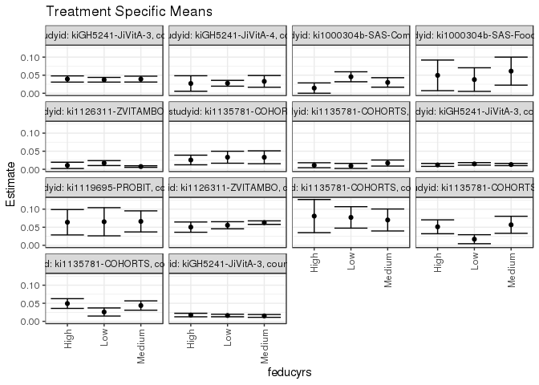

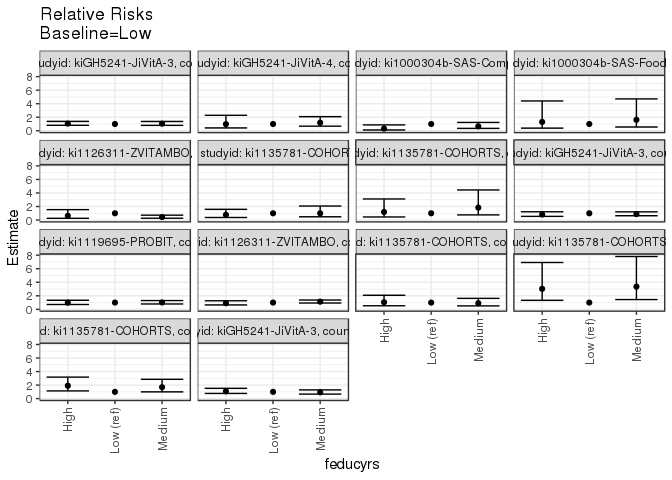

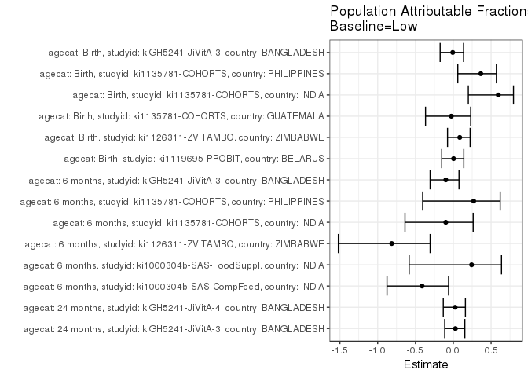

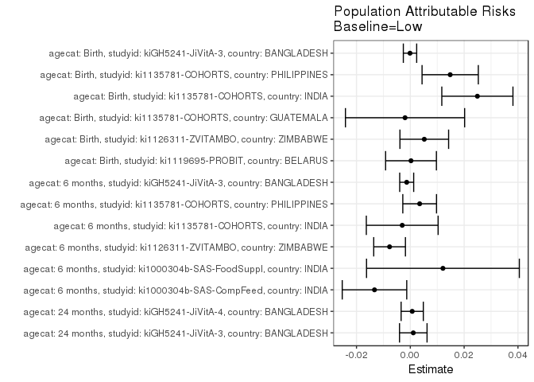

## Results Table

### Parameter: TSM

| agecat | studyid | country | intervention_level | baseline_level | estimate | ci_lower | ci_upper |
| --- | --- | --- | --- | --- | --- | --- | --- |
| Birth | ki1119695-PROBIT | BELARUS | Low | NA | 0.0651681 | 0.0261785 | 0.1041577 |
| Birth | ki1119695-PROBIT | BELARUS | Medium | NA | 0.0661679 | 0.0369848 | 0.0953510 |
| Birth | ki1119695-PROBIT | BELARUS | High | NA | 0.0639024 | 0.0287466 | 0.0990583 |
| Birth | ki1126311-ZVITAMBO | ZIMBABWE | Low | NA | 0.0555024 | 0.0456861 | 0.0653187 |
| Birth | ki1126311-ZVITAMBO | ZIMBABWE | Medium | NA | 0.0628135 | 0.0579518 | 0.0676753 |
| Birth | ki1126311-ZVITAMBO | ZIMBABWE | High | NA | 0.0503282 | 0.0361545 | 0.0645020 |
| Birth | ki1135781-COHORTS | GUATEMALA | Low | NA | 0.0771704 | 0.0474909 | 0.1068499 |
| Birth | ki1135781-COHORTS | GUATEMALA | Medium | NA | 0.0701107 | 0.0396897 | 0.1005317 |
| Birth | ki1135781-COHORTS | GUATEMALA | High | NA | 0.0808824 | 0.0350266 | 0.1267381 |
| Birth | ki1135781-COHORTS | INDIA | Low | NA | 0.0169082 | 0.0044842 | 0.0293322 |
| Birth | ki1135781-COHORTS | INDIA | Medium | NA | 0.0567568 | 0.0331717 | 0.0803418 |
| Birth | ki1135781-COHORTS | INDIA | High | NA | 0.0512821 | 0.0320749 | 0.0704892 |
| Birth | ki1135781-COHORTS | PHILIPPINES | Low | NA | 0.0258732 | 0.0146796 | 0.0370669 |
| Birth | ki1135781-COHORTS | PHILIPPINES | Medium | NA | 0.0437045 | 0.0307767 | 0.0566323 |
| Birth | ki1135781-COHORTS | PHILIPPINES | High | NA | 0.0492958 | 0.0358352 | 0.0627563 |
| Birth | kiGH5241-JiVitA-3 | BANGLADESH | Low | NA | 0.0161798 | 0.0126408 | 0.0197188 |
| Birth | kiGH5241-JiVitA-3 | BANGLADESH | Medium | NA | 0.0150434 | 0.0111068 | 0.0189800 |
| Birth | kiGH5241-JiVitA-3 | BANGLADESH | High | NA | 0.0174472 | 0.0126221 | 0.0222723 |
| 6 months | ki1000304b-SAS-CompFeed | INDIA | Low | NA | 0.0456204 | 0.0318281 | 0.0594127 |
| 6 months | ki1000304b-SAS-CompFeed | INDIA | Medium | NA | 0.0299539 | 0.0168697 | 0.0430382 |
| 6 months | ki1000304b-SAS-CompFeed | INDIA | High | NA | 0.0143266 | 0.0000589 | 0.0285944 |
| 6 months | ki1000304b-SAS-FoodSuppl | INDIA | Low | NA | 0.0378788 | 0.0052691 | 0.0704884 |
| 6 months | ki1000304b-SAS-FoodSuppl | INDIA | Medium | NA | 0.0612245 | 0.0224179 | 0.1000310 |
| 6 months | ki1000304b-SAS-FoodSuppl | INDIA | High | NA | 0.0495050 | 0.0071447 | 0.0918652 |
| 6 months | ki1126311-ZVITAMBO | ZIMBABWE | Low | NA | 0.0171674 | 0.0103579 | 0.0239769 |
| 6 months | ki1126311-ZVITAMBO | ZIMBABWE | Medium | NA | 0.0075633 | 0.0053858 | 0.0097408 |
| 6 months | ki1126311-ZVITAMBO | ZIMBABWE | High | NA | 0.0108696 | 0.0022191 | 0.0195200 |
| 6 months | ki1135781-COHORTS | INDIA | Low | NA | 0.0333333 | 0.0167422 | 0.0499245 |
| 6 months | ki1135781-COHORTS | INDIA | Medium | NA | 0.0332481 | 0.0154711 | 0.0510250 |
| 6 months | ki1135781-COHORTS | INDIA | High | NA | 0.0257353 | 0.0124244 | 0.0390462 |
| 6 months | ki1135781-COHORTS | PHILIPPINES | Low | NA | 0.0094086 | 0.0024703 | 0.0163470 |
| 6 months | ki1135781-COHORTS | PHILIPPINES | Medium | NA | 0.0172786 | 0.0088841 | 0.0256732 |
| 6 months | ki1135781-COHORTS | PHILIPPINES | High | NA | 0.0112108 | 0.0043001 | 0.0181214 |
| 6 months | kiGH5241-JiVitA-3 | BANGLADESH | Low | NA | 0.0149420 | 0.0114051 | 0.0184788 |
| 6 months | kiGH5241-JiVitA-3 | BANGLADESH | Medium | NA | 0.0131698 | 0.0100887 | 0.0162508 |
| 6 months | kiGH5241-JiVitA-3 | BANGLADESH | High | NA | 0.0121751 | 0.0080873 | 0.0162629 |
| 24 months | kiGH5241-JiVitA-3 | BANGLADESH | Low | NA | 0.0373776 | 0.0308904 | 0.0438649 |
| 24 months | kiGH5241-JiVitA-3 | BANGLADESH | Medium | NA | 0.0391121 | 0.0309781 | 0.0472460 |
| 24 months | kiGH5241-JiVitA-3 | BANGLADESH | High | NA | 0.0394161 | 0.0308508 | 0.0479813 |
| 24 months | kiGH5241-JiVitA-4 | BANGLADESH | Low | NA | 0.0276215 | 0.0195635 | 0.0356795 |
| 24 months | kiGH5241-JiVitA-4 | BANGLADESH | Medium | NA | 0.0329114 | 0.0166891 | 0.0491337 |
| 24 months | kiGH5241-JiVitA-4 | BANGLADESH | High | NA | 0.0270270 | 0.0056195 | 0.0484345 |

### Parameter: E(Y)

| agecat | studyid | country | intervention_level | baseline_level | estimate | ci_lower | ci_upper |
| --- | --- | --- | --- | --- | --- | --- | --- |
| Birth | ki1119695-PROBIT | BELARUS | NA | NA | 0.0654241 | 0.0324258 | 0.0984223 |
| Birth | ki1126311-ZVITAMBO | ZIMBABWE | NA | NA | 0.0606904 | 0.0565167 | 0.0648642 |
| Birth | ki1135781-COHORTS | GUATEMALA | NA | NA | 0.0752089 | 0.0559050 | 0.0945128 |
| Birth | ki1135781-COHORTS | INDIA | NA | NA | 0.0418280 | 0.0309034 | 0.0527527 |
| Birth | ki1135781-COHORTS | PHILIPPINES | NA | NA | 0.0406891 | 0.0332739 | 0.0481044 |
| Birth | kiGH5241-JiVitA-3 | BANGLADESH | NA | NA | 0.0160640 | 0.0136675 | 0.0184604 |
| 6 months | ki1000304b-SAS-CompFeed | INDIA | NA | NA | 0.0323065 | 0.0236135 | 0.0409996 |
| 6 months | ki1000304b-SAS-FoodSuppl | INDIA | NA | NA | 0.0500000 | 0.0280580 | 0.0719420 |
| 6 months | ki1126311-ZVITAMBO | ZIMBABWE | NA | NA | 0.0094622 | 0.0073448 | 0.0115795 |
| 6 months | ki1135781-COHORTS | INDIA | NA | NA | 0.0303249 | 0.0212906 | 0.0393592 |
| 6 months | ki1135781-COHORTS | PHILIPPINES | NA | NA | 0.0128806 | 0.0085134 | 0.0172477 |
| 6 months | kiGH5241-JiVitA-3 | BANGLADESH | NA | NA | 0.0135983 | 0.0114298 | 0.0157667 |
| 24 months | kiGH5241-JiVitA-3 | BANGLADESH | NA | NA | 0.0384802 | 0.0340611 | 0.0428992 |
| 24 months | kiGH5241-JiVitA-4 | BANGLADESH | NA | NA | 0.0283265 | 0.0213814 | 0.0352716 |

### Parameter: RR

| agecat | studyid | country | intervention_level | baseline_level | estimate | ci_lower | ci_upper |
| --- | --- | --- | --- | --- | --- | --- | --- |
| Birth | ki1119695-PROBIT | BELARUS | Low | Low | 1.0000000 | 1.0000000 | 1.0000000 |
| Birth | ki1119695-PROBIT | BELARUS | Medium | Low | 1.0153418 | 0.7935133 | 1.2991832 |
| Birth | ki1119695-PROBIT | BELARUS | High | Low | 0.9805783 | 0.7180716 | 1.3390501 |
| Birth | ki1126311-ZVITAMBO | ZIMBABWE | Low | Low | 1.0000000 | 1.0000000 | 1.0000000 |
| Birth | ki1126311-ZVITAMBO | ZIMBABWE | Medium | Low | 1.1317268 | 0.9330346 | 1.3727311 |
| Birth | ki1126311-ZVITAMBO | ZIMBABWE | High | Low | 0.9067758 | 0.6502382 | 1.2645250 |
| Birth | ki1135781-COHORTS | GUATEMALA | Low | Low | 1.0000000 | 1.0000000 | 1.0000000 |
| Birth | ki1135781-COHORTS | GUATEMALA | Medium | Low | 0.9085178 | 0.5087724 | 1.6223456 |
| Birth | ki1135781-COHORTS | GUATEMALA | High | Low | 1.0481005 | 0.5282929 | 2.0793668 |
| Birth | ki1135781-COHORTS | INDIA | Low | Low | 1.0000000 | 1.0000000 | 1.0000000 |
| Birth | ki1135781-COHORTS | INDIA | Medium | Low | 3.3567565 | 1.4431389 | 7.8078518 |
| Birth | ki1135781-COHORTS | INDIA | High | Low | 3.0329668 | 1.3294952 | 6.9190831 |
| Birth | ki1135781-COHORTS | PHILIPPINES | Low | Low | 1.0000000 | 1.0000000 | 1.0000000 |
| Birth | ki1135781-COHORTS | PHILIPPINES | Medium | Low | 1.6891779 | 1.0001523 | 2.8528877 |
| Birth | ki1135781-COHORTS | PHILIPPINES | High | Low | 1.9052817 | 1.1422872 | 3.1779209 |
| Birth | kiGH5241-JiVitA-3 | BANGLADESH | Low | Low | 1.0000000 | 1.0000000 | 1.0000000 |
| Birth | kiGH5241-JiVitA-3 | BANGLADESH | Medium | Low | 0.9297653 | 0.6690024 | 1.2921681 |
| Birth | kiGH5241-JiVitA-3 | BANGLADESH | High | Low | 1.0783338 | 0.7651174 | 1.5197718 |
| 6 months | ki1000304b-SAS-CompFeed | INDIA | Low | Low | 1.0000000 | 1.0000000 | 1.0000000 |
| 6 months | ki1000304b-SAS-CompFeed | INDIA | Medium | Low | 0.6565899 | 0.3500562 | 1.2315457 |
| 6 months | ki1000304b-SAS-CompFeed | INDIA | High | Low | 0.3140401 | 0.1134781 | 0.8690767 |
| 6 months | ki1000304b-SAS-FoodSuppl | INDIA | Low | Low | 1.0000000 | 1.0000000 | 1.0000000 |
| 6 months | ki1000304b-SAS-FoodSuppl | INDIA | Medium | Low | 1.6163265 | 0.5549340 | 4.7077878 |
| 6 months | ki1000304b-SAS-FoodSuppl | INDIA | High | Low | 1.3069307 | 0.3882428 | 4.3994837 |
| 6 months | ki1126311-ZVITAMBO | ZIMBABWE | Low | Low | 1.0000000 | 1.0000000 | 1.0000000 |
| 6 months | ki1126311-ZVITAMBO | ZIMBABWE | Medium | Low | 0.4405623 | 0.2698667 | 0.7192260 |
| 6 months | ki1126311-ZVITAMBO | ZIMBABWE | High | Low | 0.6331522 | 0.2602129 | 1.5405909 |
| 6 months | ki1135781-COHORTS | INDIA | Low | Low | 1.0000000 | 1.0000000 | 1.0000000 |
| 6 months | ki1135781-COHORTS | INDIA | Medium | Low | 0.9974425 | 0.4804402 | 2.0707914 |
| 6 months | ki1135781-COHORTS | INDIA | High | Low | 0.7720588 | 0.3766227 | 1.5826844 |
| 6 months | ki1135781-COHORTS | PHILIPPINES | Low | Low | 1.0000000 | 1.0000000 | 1.0000000 |
| 6 months | ki1135781-COHORTS | PHILIPPINES | Medium | Low | 1.8364702 | 0.7593796 | 4.4412874 |
| 6 months | ki1135781-COHORTS | PHILIPPINES | High | Low | 1.1915439 | 0.4557076 | 3.1155434 |
| 6 months | kiGH5241-JiVitA-3 | BANGLADESH | Low | Low | 1.0000000 | 1.0000000 | 1.0000000 |
| 6 months | kiGH5241-JiVitA-3 | BANGLADESH | Medium | Low | 0.8813934 | 0.6392075 | 1.2153400 |
| 6 months | kiGH5241-JiVitA-3 | BANGLADESH | High | Low | 0.8148274 | 0.5430536 | 1.2226116 |
| 24 months | kiGH5241-JiVitA-3 | BANGLADESH | Low | Low | 1.0000000 | 1.0000000 | 1.0000000 |
| 24 months | kiGH5241-JiVitA-3 | BANGLADESH | Medium | Low | 1.0464026 | 0.7970332 | 1.3737926 |
| 24 months | kiGH5241-JiVitA-3 | BANGLADESH | High | Low | 1.0545360 | 0.8043301 | 1.3825744 |
| 24 months | kiGH5241-JiVitA-4 | BANGLADESH | Low | Low | 1.0000000 | 1.0000000 | 1.0000000 |
| 24 months | kiGH5241-JiVitA-4 | BANGLADESH | Medium | Low | 1.1915143 | 0.6821170 | 2.0813238 |
| 24 months | kiGH5241-JiVitA-4 | BANGLADESH | High | Low | 0.9784785 | 0.4185764 | 2.2873249 |

### Parameter: PAR

| agecat | studyid | country | intervention_level | baseline_level | estimate | ci_lower | ci_upper |
| --- | --- | --- | --- | --- | --- | --- | --- |
| Birth | ki1119695-PROBIT | BELARUS | Low | NA | 0.0002559 | -0.0091846 | 0.0096965 |
| Birth | ki1126311-ZVITAMBO | ZIMBABWE | Low | NA | 0.0051880 | -0.0038531 | 0.0142292 |
| Birth | ki1135781-COHORTS | GUATEMALA | Low | NA | -0.0019615 | -0.0241069 | 0.0201839 |
| Birth | ki1135781-COHORTS | INDIA | Low | NA | 0.0249198 | 0.0117022 | 0.0381375 |
| Birth | ki1135781-COHORTS | PHILIPPINES | Low | NA | 0.0148159 | 0.0043625 | 0.0252694 |
| Birth | kiGH5241-JiVitA-3 | BANGLADESH | Low | NA | -0.0001158 | -0.0025950 | 0.0023634 |
| 6 months | ki1000304b-SAS-CompFeed | INDIA | Low | NA | -0.0133139 | -0.0252994 | -0.0013285 |
| 6 months | ki1000304b-SAS-FoodSuppl | INDIA | Low | NA | 0.0121212 | -0.0162700 | 0.0405125 |
| 6 months | ki1126311-ZVITAMBO | ZIMBABWE | Low | NA | -0.0077052 | -0.0135968 | -0.0018136 |
| 6 months | ki1135781-COHORTS | INDIA | Low | NA | -0.0030084 | -0.0163505 | 0.0103336 |
| 6 months | ki1135781-COHORTS | PHILIPPINES | Low | NA | 0.0034720 | -0.0027932 | 0.0097371 |
| 6 months | kiGH5241-JiVitA-3 | BANGLADESH | Low | NA | -0.0013437 | -0.0039395 | 0.0012520 |
| 24 months | kiGH5241-JiVitA-3 | BANGLADESH | Low | NA | 0.0011025 | -0.0040138 | 0.0062188 |
| 24 months | kiGH5241-JiVitA-4 | BANGLADESH | Low | NA | 0.0007050 | -0.0034226 | 0.0048327 |

### Parameter: PAF

| agecat | studyid | country | intervention_level | baseline_level | estimate | ci_lower | ci_upper |
| --- | --- | --- | --- | --- | --- | --- | --- |
| Birth | ki1119695-PROBIT | BELARUS | Low | NA | 0.0039121 | -0.1526259 | 0.1391907 |
| Birth | ki1126311-ZVITAMBO | ZIMBABWE | Low | NA | 0.0854835 | -0.0761874 | 0.2228673 |
| Birth | ki1135781-COHORTS | GUATEMALA | Low | NA | -0.0260807 | -0.3670453 | 0.2298414 |
| Birth | ki1135781-COHORTS | INDIA | Low | NA | 0.5957684 | 0.1987230 | 0.7960716 |
| Birth | ki1135781-COHORTS | PHILIPPINES | Low | NA | 0.3641248 | 0.0598207 | 0.5699360 |
| Birth | kiGH5241-JiVitA-3 | BANGLADESH | Low | NA | -0.0072077 | -0.1739291 | 0.1358360 |
| 6 months | ki1000304b-SAS-CompFeed | INDIA | Low | NA | -0.4121117 | -0.8768003 | -0.0624782 |
| 6 months | ki1000304b-SAS-FoodSuppl | INDIA | Low | NA | 0.2424242 | -0.5835860 | 0.6375814 |
| 6 months | ki1126311-ZVITAMBO | ZIMBABWE | Low | NA | -0.8143212 | -1.5203629 | -0.3060664 |
| 6 months | ki1135781-COHORTS | INDIA | Low | NA | -0.0992063 | -0.6388727 | 0.2627526 |
| 6 months | ki1135781-COHORTS | PHILIPPINES | Low | NA | 0.2695503 | -0.4051910 | 0.6202960 |
| 6 months | kiGH5241-JiVitA-3 | BANGLADESH | Low | NA | -0.0988155 | -0.3062811 | 0.0757000 |
| 24 months | kiGH5241-JiVitA-3 | BANGLADESH | Low | NA | 0.0286517 | -0.1135813 | 0.1527179 |
| 24 months | kiGH5241-JiVitA-4 | BANGLADESH | Low | NA | 0.0248889 | -0.1323848 | 0.1603194 |